# Entwurf: Quantifizierung und regionale Trends des Facharztmangels im Öffentlichen Gesundheitsdienst (ÖGD)

### Tabelle 3a: Bei den Ärztekammern registrierte tätigen Ärztinnen und Ärzte nach Facharztrichtungen in Deutschland zwischen 1998 und 2018

| Facharzt | 1998 | 1999 | 2000 | 2001 | 2002 | 2003 | 2004 | 2005 | 2006 | 2007 | 2008 | 2009 | 2010 | 2011 | 2012 | 2013 | 2014 | 2015 | 2016 | 2017 | 2018 |
| --- | --- | --- | --- | --- | --- | --- | --- | --- | --- | --- | --- | --- | --- | --- | --- | --- | --- | --- | --- | --- | --- |
| Allgemeinmedizin | 35599 (0 %) | 36427 (2.3 %) | 36963 (3.8 %) | 37836 (6.3 %) | 38711 (8.7 %) | 39238 (10.2 %) | 39981 (12.3 %) | 43167 (21.3 %) | 42256 (18.7 %) | 42744 (20.1 %) | 42730 (20 %) | 42897 (20.5 %) | 43103 (21.1 %) | 43190 (21.3 %) | 43304 (21.6 %) | 43248 (21.5 %) | 43206 (21.4 %) | 43569 (22.4 %) | 43618 (22.5 %) | 43524 (22.3 %) | 43697 (22.7 %) |
| Anästhesiologie | 13779 (0 %) | 14354 (4.2 %) | 14827 (7.6 %) | 15240 (10.6 %) | 15630 (13.4 %) | 16108 (16.9 %) | 16473 (19.6 %) | 16951 (23 %) | 17418 (26.4 %) | 17891 (29.8 %) | 18327 (33 %) | 18868 (36.9 %) | 19413 (40.9 %) | 20144 (46.2 %) | 20836 (51.2 %) | 21478 (55.9 %) | 22071 (60.2 %) | 22875 (66 %) | 23531 (70.8 %) | 24301 (76.4 %) | 24970 (81.2 %) |
| Anatomie | 134 (0 %) | 142 (6 %) | 136 (1.5 %) | 136 (1.5 %) | 134 (0 %) | 129 (-3.7 %) | 132 (-1.5 %) | 125 (-6.7 %) | 118 (-11.9 %) | 110 (-17.9 %) | 104 (-22.4 %) | 97 (-27.6 %) | 100 (-25.4 %) | 102 (-23.9 %) | 103 (-23.1 %) | 107 (-20.1 %) | 108 (-19.4 %) | 113 (-15.7 %) | 115 (-14.2 %) | 114 (-14.9 %) | 110 (-17.9 %) |
| Arbeitsmedizin | 2614 (0 %) | 2649 (1.3 %) | 2624 (0.4 %) | 2664 (1.9 %) | 2679 (2.5 %) | 2654 (1.5 %) | 2665 (2 %) | 2697 (3.2 %) | 2703 (3.4 %) | 2721 (4.1 %) | 2728 (4.4 %) | 2762 (5.7 %) | 2821 (7.9 %) | 2863 (9.5 %) | 2926 (11.9 %) | 3006 (15 %) | 3112 (19.1 %) | 3194 (22.2 %) | 3282 (25.6 %) | 3370 (28.9 %) | 3519 (34.6 %) |
| Augenheilkunde | 6305 (0 %) | 6296 (-0.1 %) | 6336 (0.5 %) | 6378 (1.2 %) | 6411 (1.7 %) | 6461 (2.5 %) | 6472 (2.6 %) | 6527 (3.5 %) | 6544 (3.8 %) | 6613 (4.9 %) | 6638 (5.3 %) | 6756 (7.2 %) | 6805 (7.9 %) | 6910 (9.6 %) | 6980 (10.7 %) | 7076 (12.2 %) | 7156 (13.5 %) | 7298 (15.7 %) | 7388 (17.2 %) | 7497 (18.9 %) | 7639 (21.2 %) |
| Biochemie | 93 (0 %) | 93 (0 %) | 87 (-6.5 %) | 86 (-7.5 %) | 85 (-8.6 %) | 72 (-22.6 %) | 66 (-29 %) | 61 (-34.4 %) | 61 (-34.4 %) | 56 (-39.8 %) | 58 (-37.6 %) | 50 (-46.2 %) | 50 (-46.2 %) | 53 (-43 %) | 48 (-48.4 %) | 47 (-49.5 %) | 46 (-50.5 %) | 47 (-49.5 %) | 41 (-55.9 %) | 39 (-58.1 %) | 37 (-60.2 %) |
| Chirurgie | 23113 (0 %) | 23829 (3.1 %) | 24426 (5.7 %) | 25132 (8.7 %) | 25809 (11.7 %) | 26570 (15 %) | 27187 (17.6 %) | 27784 (20.2 %) | 28414 (22.9 %) | 29048 (25.7 %) | 29602 (28.1 %) | 30386 (31.5 %) | 31166 (34.8 %) | 32028 (38.6 %) | 32906 (42.4 %) | 33621 (45.5 %) | 34276 (48.3 %) | 35324 (52.8 %) | 36148 (56.4 %) | 36991 (60 %) | 37853 (63.8 %) |
| Frauenheilkunde und Geburtshilfe | 14327 (0 %) | 14614 (2 %) | 14815 (3.4 %) | 15041 (5 %) | 15228 (6.3 %) | 15384 (7.4 %) | 15490 (8.1 %) | 15605 (8.9 %) | 15811 (10.4 %) | 15950 (11.3 %) | 16134 (12.6 %) | 16369 (14.3 %) | 16599 (15.9 %) | 16861 (17.7 %) | 17147 (19.7 %) | 17337 (21 %) | 17651 (23.2 %) | 17994 (25.6 %) | 18253 (27.4 %) | 18427 (28.6 %) | 18622 (30 %) |
| Gesamt | 287032 (0 %) | 291171 (1.4 %) | 294676 (2.7 %) | 297893 (3.8 %) | 301060 (4.9 %) | 304117 (6 %) | 306435 (6.8 %) | 307577 (7.2 %) | 311230 (8.4 %) | 314912 (9.7 %) | 319697 (11.4 %) | 325945 (13.6 %) | 333599 (16.2 %) | 342063 (19.2 %) | 348695 (21.5 %) | 357252 (24.5 %) | 365247 (27.2 %) | 371302 (29.4 %) | 378607 (31.9 %) | 385149 (34.2 %) | 392402 (36.7 %) |
| Hals-Nasen-Ohrenheilkunde | 5172 (0 %) | 5204 (0.6 %) | 5264 (1.8 %) | 5319 (2.8 %) | 5358 (3.6 %) | 5420 (4.8 %) | 5467 (5.7 %) | 5476 (5.9 %) | 5527 (6.9 %) | 5566 (7.6 %) | 5566 (7.6 %) | 5631 (8.9 %) | 5696 (10.1 %) | 5804 (12.2 %) | 5922 (14.5 %) | 5952 (15.1 %) | 6083 (17.6 %) | 6206 (20 %) | 6273 (21.3 %) | 6295 (21.7 %) | 6383 (23.4 %) |
| Haut- und Geschlechtskrankheiten | 4429 (0 %) | 4519 (2 %) | 4626 (4.4 %) | 4705 (6.2 %) | 4778 (7.9 %) | 4867 (9.9 %) | 4915 (11 %) | 5012 (13.2 %) | 5071 (14.5 %) | 5114 (15.5 %) | 5180 (17 %) | 5250 (18.5 %) | 5314 (20 %) | 5411 (22.2 %) | 5519 (24.6 %) | 5584 (26.1 %) | 5652 (27.6 %) | 5767 (30.2 %) | 5860 (32.3 %) | 5944 (34.2 %) | 6057 (36.8 %) |
| Humangenetik | 151 (0 %) | 159 (5.3 %) | 181 (19.9 %) | 179 (18.5 %) | 194 (28.5 %) | 190 (25.8 %) | 206 (36.4 %) | 220 (45.7 %) | 227 (50.3 %) | 235 (55.6 %) | 251 (66.2 %) | 265 (75.5 %) | 281 (86.1 %) | 295 (95.4 %) | 310 (105.3 %) | 320 (111.9 %) | 322 (113.2 %) | 341 (125.8 %) | 342 (126.5 %) | 363 (140.4 %) | 359 (137.7 %) |
| Hygiene und Umweltmedizin | 289 (0 %) | 282 (-2.4 %) | 271 (-6.2 %) | 267 (-7.6 %) | 257 (-11.1 %) | 244 (-15.6 %) | 231 (-20.1 %) | 218 (-24.6 %) | 212 (-26.6 %) | 212 (-26.6 %) | 207 (-28.4 %) | 204 (-29.4 %) | 201 (-30.4 %) | 201 (-30.4 %) | 201 (-30.4 %) | 195 (-32.5 %) | 198 (-31.5 %) | 199 (-31.1 %) | 204 (-29.4 %) | 206 (-28.7 %) | 212 (-26.6 %) |
| Innere Medizin | 34653 (0 %) | 35431 (2.2 %) | 35955 (3.8 %) | 36817 (6.2 %) | 37584 (8.5 %) | 38395 (10.8 %) | 39125 (12.9 %) | 39630 (14.4 %) | 40337 (16.4 %) | 40980 (18.3 %) | 41722 (20.4 %) | 42703 (23.2 %) | 43955 (26.8 %) | 45559 (31.5 %) | 46995 (35.6 %) | 48090 (38.8 %) | 49093 (41.7 %) | 50834 (46.7 %) | 52158 (50.5 %) | 53362 (54 %) | 54982 (58.7 %) |
| Kinder- und Jugendmedizin | 11044 (0 %) | 11178 (1.2 %) | 11196 (1.4 %) | 11227 (1.7 %) | 11302 (2.3 %) | 11354 (2.8 %) | 11419 (3.4 %) | 11489 (4 %) | 11640 (5.4 %) | 11788 (6.7 %) | 11973 (8.4 %) | 12216 (10.6 %) | 12503 (13.2 %) | 12841 (16.3 %) | 13179 (19.3 %) | 13464 (21.9 %) | 13718 (24.2 %) | 14162 (28.2 %) | 14466 (31 %) | 14703 (33.1 %) | 14999 (35.8 %) |
| Kinder- und Jugendpsychiatrie und -psychotherapie | 910 (0 %) | 967 (6.3 %) | 1026 (12.7 %) | 1073 (17.9 %) | 1131 (24.3 %) | 1166 (28.1 %) | 1236 (35.8 %) | 1299 (42.7 %) | 1354 (48.8 %) | 1414 (55.4 %) | 1503 (65.2 %) | 1587 (74.4 %) | 1682 (84.8 %) | 1806 (98.5 %) | 1885 (107.1 %) | 1965 (115.9 %) | 2039 (124.1 %) | 2168 (138.2 %) | 2259 (148.2 %) | 2346 (157.8 %) | 2449 (169.1 %) |
| Laboratoriumsmedizin | 924 (0 %) | 906 (-1.9 %) | 899 (-2.7 %) | 927 (0.3 %) | 939 (1.6 %) | 953 (3.1 %) | 949 (2.7 %) | 951 (2.9 %) | 942 (1.9 %) | 945 (2.3 %) | 977 (5.7 %) | 1000 (8.2 %) | 995 (7.7 %) | 1019 (10.3 %) | 1038 (12.3 %) | 1052 (13.9 %) | 1064 (15.2 %) | 1090 (18 %) | 1112 (20.3 %) | 1125 (21.8 %) | 1146 (24 %) |
| Mikrobiologie, Virologie, Infektionsepidemiologie | 587 (0 %) | 586 (-0.2 %) | 600 (2.2 %) | 610 (3.9 %) | 610 (3.9 %) | 629 (7.2 %) | 636 (8.3 %) | 646 (10.1 %) | 645 (9.9 %) | 652 (11.1 %) | 666 (13.5 %) | 664 (13.1 %) | 671 (14.3 %) | 696 (18.6 %) | 697 (18.7 %) | 713 (21.5 %) | 731 (24.5 %) | 768 (30.8 %) | 776 (32.2 %) | 797 (35.8 %) | 817 (39.2 %) |
| Mund-Kiefer-Gesichtschirurgie | 1048 (0 %) | 1078 (2.9 %) | 1124 (7.3 %) | 1169 (11.5 %) | 1234 (17.7 %) | 1268 (21 %) | 1308 (24.8 %) | 1324 (26.3 %) | 1357 (29.5 %) | 1411 (34.6 %) | 1445 (37.9 %) | 1474 (40.6 %) | 1491 (42.3 %) | 1519 (44.9 %) | 1544 (47.3 %) | 1582 (51 %) | 1633 (55.8 %) | 1654 (57.8 %) | 1694 (61.6 %) | 1733 (65.4 %) | 1766 (68.5 %) |
| Neurochirurgie | 867 (0 %) | 930 (7.3 %) | 973 (12.2 %) | 1063 (22.6 %) | 1125 (29.8 %) | 1213 (39.9 %) | 1257 (45 %) | 1309 (51 %) | 1379 (59.1 %) | 1436 (65.6 %) | 1464 (68.9 %) | 1533 (76.8 %) | 1594 (83.9 %) | 1681 (93.9 %) | 1784 (105.8 %) | 1860 (114.5 %) | 1952 (125.1 %) | 2071 (138.9 %) | 2170 (150.3 %) | 2260 (160.7 %) | 2363 (172.5 %) |
| Neurologie | 1961 (0 %) | 2276 (16.1 %) | 2226 (13.5 %) | 2423 (23.6 %) | 2641 (34.7 %) | 2847 (45.2 %) | 3260 (66.2 %) | 3548 (80.9 %) | 3708 (89.1 %) | 3999 (103.9 %) | 4238 (116.1 %) | 4540 (131.5 %) | 4804 (145 %) | 5074 (158.7 %) | 5370 (173.8 %) | 5727 (192 %) | 6095 (210.8 %) | 6451 (229 %) | 6810 (247.3 %) | 7188 (266.5 %) | 7537 (284.3 %) |
| Nuklearmedizin | 724 (0 %) | 753 (4 %) | 810 (11.9 %) | 828 (14.4 %) | 857 (18.4 %) | 894 (23.5 %) | 904 (24.9 %) | 929 (28.3 %) | 955 (31.9 %) | 955 (31.9 %) | 984 (35.9 %) | 1017 (40.5 %) | 1046 (44.5 %) | 1054 (45.6 %) | 1074 (48.3 %) | 1108 (53 %) | 1126 (55.5 %) | 1144 (58 %) | 1160 (60.2 %) | 1177 (62.6 %) | 1190 (64.4 %) |
| Öffentliches Gesundheitswesen | 1072 (0 %) | 1063 (-0.8 %) | 1079 (0.7 %) | 1047 (-2.3 %) | 1053 (-1.8 %) | 1034 (-3.5 %) | 1015 (-5.3 %) | 969 (-9.6 %) | 961 (-10.4 %) | 958 (-10.6 %) | 919 (-14.3 %) | 892 (-16.8 %) | 882 (-17.7 %) | 866 (-19.2 %) | 857 (-20.1 %) | 840 (-21.6 %) | 844 (-21.3 %) | 811 (-24.3 %) | 800 (-25.4 %) | 785 (-26.8 %) | 784 (-26.9 %) |
| Pathologie | 1314 (0 %) | 1330 (1.2 %) | 1357 (3.3 %) | 1377 (4.8 %) | 1389 (5.7 %) | 1396 (6.2 %) | 1408 (7.2 %) | 1372 (4.4 %) | 1400 (6.5 %) | 1384 (5.3 %) | 1405 (6.9 %) | 1441 (9.7 %) | 1465 (11.5 %) | 1501 (14.2 %) | 1535 (16.8 %) | 1582 (20.4 %) | 1605 (22.1 %) | 1652 (25.7 %) | 1676 (27.5 %) | 1708 (30 %) | 1735 (32 %) |
| Pharmakologie | 492 (0 %) | 497 (1 %) | 506 (2.8 %) | 506 (2.8 %) | 497 (1 %) | 495 (0.6 %) | 490 (-0.4 %) | 473 (-3.9 %) | 481 (-2.2 %) | 459 (-6.7 %) | 452 (-8.1 %) | 444 (-9.8 %) | 449 (-8.7 %) | 444 (-9.8 %) | 443 (-10 %) | 451 (-8.3 %) | 466 (-5.3 %) | 453 (-7.9 %) | 436 (-11.4 %) | 421 (-14.4 %) | 408 (-17.1 %) |
| Physikalische und Rehabilitative Medizin | 1303 (0 %) | 1405 (7.8 %) | 1612 (23.7 %) | 1609 (23.5 %) | 1656 (27.1 %) | 1677 (28.7 %) | 1683 (29.2 %) | 1680 (28.9 %) | 1680 (28.9 %) | 1660 (27.4 %) | 1684 (29.2 %) | 1705 (30.9 %) | 1725 (32.4 %) | 1753 (34.5 %) | 1793 (37.6 %) | 1815 (39.3 %) | 1829 (40.4 %) | 1872 (43.7 %) | 1865 (43.1 %) | 1862 (42.9 %) | 1882 (44.4 %) |
| Physiologie | 119 (0 %) | 122 (2.5 %) | 115 (-3.4 %) | 116 (-2.5 %) | 114 (-4.2 %) | 112 (-5.9 %) | 109 (-8.4 %) | 112 (-5.9 %) | 108 (-9.2 %) | 100 (-16 %) | 95 (-20.2 %) | 96 (-19.3 %) | 92 (-22.7 %) | 97 (-18.5 %) | 105 (-11.8 %) | 107 (-10.1 %) | 105 (-11.8 %) | 102 (-14.3 %) | 99 (-16.8 %) | 100 (-16 %) | 101 (-15.1 %) |
| Psychiatrie und Psychotherapie | 3760 (0 %) | 4190 (11.4 %) | 4736 (26 %) | 5183 (37.8 %) | 5597 (48.9 %) | 5992 (59.4 %) | 6378 (69.6 %) | 6802 (80.9 %) | 7148 (90.1 %) | 7499 (99.4 %) | 7856 (108.9 %) | 8297 (120.7 %) | 8663 (130.4 %) | 9105 (142.2 %) | 9485 (152.3 %) | 9770 (159.8 %) | 10088 (168.3 %) | 10450 (177.9 %) | 10787 (186.9 %) | 11037 (193.5 %) | 11346 (201.8 %) |
| Psychosomatische Medizin und Psychotherapie | 2872 (0 %) | 3144 (9.5 %) | 3543 (23.4 %) | 3541 (23.3 %) | 3655 (27.3 %) | 3757 (30.8 %) | 3816 (32.9 %) | 3840 (33.7 %) | 3861 (34.4 %) | 3874 (34.9 %) | 3890 (35.4 %) | 3945 (37.4 %) | 3981 (38.6 %) | 4024 (40.1 %) | 4066 (41.6 %) | 4080 (42.1 %) | 4123 (43.6 %) | 4179 (45.5 %) | 4181 (45.6 %) | 4142 (44.2 %) | 4155 (44.7 %) |
| Radiologie | 5725 (0 %) | 5897 (3 %) | 5914 (3.3 %) | 6097 (6.5 %) | 6160 (7.6 %) | 6252 (9.2 %) | 6314 (10.3 %) | 6405 (11.9 %) | 6456 (12.8 %) | 6631 (15.8 %) | 6690 (16.9 %) | 6806 (18.9 %) | 6989 (22.1 %) | 7193 (25.6 %) | 7379 (28.9 %) | 7546 (31.8 %) | 7745 (35.3 %) | 7969 (39.2 %) | 8246 (44 %) | 8533 (49 %) | 8792 (53.6 %) |
| Rechtsmedizin | 220 (0 %) | 214 (-2.7 %) | 210 (-4.5 %) | 204 (-7.3 %) | 218 (-0.9 %) | 216 (-1.8 %) | 213 (-3.2 %) | 219 (-0.5 %) | 211 (-4.1 %) | 207 (-5.9 %) | 210 (-4.5 %) | 214 (-2.7 %) | 213 (-3.2 %) | 219 (-0.5 %) | 229 (4.1 %) | 235 (6.8 %) | 239 (8.6 %) | 245 (11.4 %) | 248 (12.7 %) | 253 (15 %) | 263 (19.5 %) |
| Strahlentherapie | 457 (0 %) | 526 (15.1 %) | 591 (29.3 %) | 630 (37.9 %) | 680 (48.8 %) | 734 (60.6 %) | 777 (70 %) | 805 (76.1 %) | 844 (84.7 %) | 894 (95.6 %) | 933 (104.2 %) | 989 (116.4 %) | 1059 (131.7 %) | 1084 (137.2 %) | 1142 (149.9 %) | 1192 (160.8 %) | 1228 (168.7 %) | 1257 (175.1 %) | 1302 (184.9 %) | 1368 (199.3 %) | 1420 (210.7 %) |
| Transfusionsmedizin | 381 (0 %) | 395 (3.7 %) | 426 (11.8 %) | 434 (13.9 %) | 477 (25.2 %) | 493 (29.4 %) | 508 (33.3 %) | 499 (31 %) | 512 (34.4 %) | 521 (36.7 %) | 520 (36.5 %) | 524 (37.5 %) | 537 (40.9 %) | 551 (44.6 %) | 562 (47.5 %) | 577 (51.4 %) | 588 (54.3 %) | 594 (55.9 %) | 603 (58.3 %) | 594 (55.9 %) | 584 (53.3 %) |
| Urologie | 4186 (0 %) | 4282 (2.3 %) | 4384 (4.7 %) | 4491 (7.3 %) | 4568 (9.1 %) | 4651 (11.1 %) | 4762 (13.8 %) | 4804 (14.8 %) | 4883 (16.7 %) | 4950 (18.3 %) | 5040 (20.4 %) | 5117 (22.2 %) | 5204 (24.3 %) | 5311 (26.9 %) | 5388 (28.7 %) | 5521 (31.9 %) | 5635 (34.6 %) | 5771 (37.9 %) | 5883 (40.5 %) | 5936 (41.8 %) | 6075 (45.1 %) |

### Tabelle 3b: Bei den Ärztekammern registrierte in Behörden, Körperschaften oder ähnlichen Einrichtungen tätigen Ärztinnen und Ärzte nach Facharztrichtungen in Deutschland zwischen 1998 und 2018

| Facharzt | 1998 | 1999 | 2000 | 2001 | 2002 | 2003 | 2004 | 2005 | 2006 | 2007 | 2008 | 2009 | 2010 | 2011 | 2012 | 2013 | 2014 | 2015 | 2016 | 2017 | 2018 |
| --- | --- | --- | --- | --- | --- | --- | --- | --- | --- | --- | --- | --- | --- | --- | --- | --- | --- | --- | --- | --- | --- |
| Allgemeinmedizin | 1203 (0 %) | 1219 (1.3 %) | 1188 (-1.2 %) | 1239 (3 %) | 1303 (8.3 %) | 1325 (10.1 %) | 1383 (15 %) | 1471 (22.3 %) | 1419 (18 %) | 1360 (13.1 %) | 1314 (9.2 %) | 1268 (5.4 %) | 1282 (6.6 %) | 1273 (5.8 %) | 1277 (6.2 %) | 1274 (5.9 %) | 1281 (6.5 %) | 1236 (2.7 %) | 1219 (1.3 %) | 1228 (2.1 %) | 1222 (1.6 %) |
| Anästhesiologie | 190 (0 %) | 181 (-4.7 %) | 191 (0.5 %) | 211 (11.1 %) | 216 (13.7 %) | 220 (15.8 %) | 236 (24.2 %) | 241 (26.8 %) | 247 (30 %) | 263 (38.4 %) | 264 (38.9 %) | 264 (38.9 %) | 289 (52.1 %) | 293 (54.2 %) | 309 (62.6 %) | 334 (75.8 %) | 362 (90.5 %) | 390 (105.3 %) | 403 (112.1 %) | 412 (116.8 %) | 446 (134.7 %) |
| Anatomie | 22 (0 %) | 23 (4.5 %) | 21 (-4.5 %) | 20 (-9.1 %) | 23 (4.5 %) | 21 (-4.5 %) | 22 (0 %) | 13 (-40.9 %) | 13 (-40.9 %) | 16 (-27.3 %) | 15 (-31.8 %) | 13 (-40.9 %) | 12 (-45.5 %) | 15 (-31.8 %) | 15 (-31.8 %) | 15 (-31.8 %) | 15 (-31.8 %) | 15 (-31.8 %) | 16 (-27.3 %) | 18 (-18.2 %) | 17 (-22.7 %) |
| Arbeitsmedizin | 534 (0 %) | 523 (-2.1 %) | 474 (-11.2 %) | 478 (-10.5 %) | 477 (-10.7 %) | 462 (-13.5 %) | 470 (-12 %) | 423 (-20.8 %) | 407 (-23.8 %) | 416 (-22.1 %) | 402 (-24.7 %) | 376 (-29.6 %) | 387 (-27.5 %) | 387 (-27.5 %) | 388 (-27.3 %) | 379 (-29 %) | 381 (-28.7 %) | 377 (-29.4 %) | 371 (-30.5 %) | 364 (-31.8 %) | 376 (-29.6 %) |
| Augenheilkunde | 29 (0 %) | 26 (-10.3 %) | 31 (6.9 %) | 38 (31 %) | 33 (13.8 %) | 33 (13.8 %) | 37 (27.6 %) | 38 (31 %) | 41 (41.4 %) | 41 (41.4 %) | 35 (20.7 %) | 36 (24.1 %) | 37 (27.6 %) | 36 (24.1 %) | 39 (34.5 %) | 40 (37.9 %) | 42 (44.8 %) | 41 (41.4 %) | 41 (41.4 %) | 42 (44.8 %) | 48 (65.5 %) |
| Biochemie | 18 (0 %) | 16 (-11.1 %) | 17 (-5.6 %) | 19 (5.6 %) | 19 (5.6 %) | 16 (-11.1 %) | 13 (-27.8 %) | 4 (-77.8 %) | 5 (-72.2 %) | 5 (-72.2 %) | 6 (-66.7 %) | 5 (-72.2 %) | 4 (-77.8 %) | 2 (-88.9 %) | 2 (-88.9 %) | 2 (-88.9 %) | 3 (-83.3 %) | 2 (-88.9 %) | 2 (-88.9 %) | 2 (-88.9 %) | 3 (-83.3 %) |
| Chirurgie | 555 (0 %) | 551 (-0.7 %) | 517 (-6.8 %) | 534 (-3.8 %) | 548 (-1.3 %) | 566 (2 %) | 581 (4.7 %) | 561 (1.1 %) | 606 (9.2 %) | 600 (8.1 %) | 617 (11.2 %) | 611 (10.1 %) | 613 (10.5 %) | 602 (8.5 %) | 590 (6.3 %) | 598 (7.7 %) | 597 (7.6 %) | 601 (8.3 %) | 603 (8.6 %) | 617 (11.2 %) | 640 (15.3 %) |
| Frauenheilkunde und Geburtshilfe | 82 (0 %) | 84 (2.4 %) | 87 (6.1 %) | 97 (18.3 %) | 98 (19.5 %) | 108 (31.7 %) | 115 (40.2 %) | 106 (29.3 %) | 109 (32.9 %) | 107 (30.5 %) | 103 (25.6 %) | 110 (34.1 %) | 116 (41.5 %) | 121 (47.6 %) | 129 (57.3 %) | 134 (63.4 %) | 140 (70.7 %) | 151 (84.1 %) | 160 (95.1 %) | 173 (111 %) | 176 (114.6 %) |
| Hals-Nasen-Ohrenheilkunde | 68 (0 %) | 63 (-7.4 %) | 63 (-7.4 %) | 70 (2.9 %) | 70 (2.9 %) | 65 (-4.4 %) | 64 (-5.9 %) | 62 (-8.8 %) | 67 (-1.5 %) | 67 (-1.5 %) | 70 (2.9 %) | 65 (-4.4 %) | 72 (5.9 %) | 70 (2.9 %) | 74 (8.8 %) | 78 (14.7 %) | 78 (14.7 %) | 80 (17.6 %) | 76 (11.8 %) | 83 (22.1 %) | 88 (29.4 %) |
| Haut- und Geschlechtskrankheiten | 72 (0 %) | 68 (-5.6 %) | 74 (2.8 %) | 78 (8.3 %) | 77 (6.9 %) | 77 (6.9 %) | 80 (11.1 %) | 78 (8.3 %) | 84 (16.7 %) | 81 (12.5 %) | 84 (16.7 %) | 84 (16.7 %) | 93 (29.2 %) | 96 (33.3 %) | 100 (38.9 %) | 93 (29.2 %) | 90 (25 %) | 89 (23.6 %) | 95 (31.9 %) | 98 (36.1 %) | 106 (47.2 %) |
| Humangenetik | 12 (0 %) | 13 (8.3 %) | 16 (33.3 %) | 14 (16.7 %) | 15 (25 %) | 15 (25 %) | 16 (33.3 %) | 12 (0 %) | 9 (-25 %) | 8 (-33.3 %) | 10 (-16.7 %) | 11 (-8.3 %) | 12 (0 %) | 13 (8.3 %) | 12 (0 %) | 12 (0 %) | 11 (-8.3 %) | 11 (-8.3 %) | 11 (-8.3 %) | 8 (-33.3 %) | 9 (-25 %) |
| Hygiene und Umweltmedizin | 113 (0 %) | 109 (-3.5 %) | 109 (-3.5 %) | 113 (0 %) | 113 (0 %) | 107 (-5.3 %) | 101 (-10.6 %) | 94 (-16.8 %) | 85 (-24.8 %) | 85 (-24.8 %) | 83 (-26.5 %) | 76 (-32.7 %) | 73 (-35.4 %) | 66 (-41.6 %) | 70 (-38.1 %) | 61 (-46 %) | 60 (-46.9 %) | 54 (-52.2 %) | 55 (-51.3 %) | 57 (-49.6 %) | 53 (-53.1 %) |
| Innere Medizin | 1135 (0 %) | 1108 (-2.4 %) | 1052 (-7.3 %) | 1086 (-4.3 %) | 1105 (-2.6 %) | 1083 (-4.6 %) | 1079 (-4.9 %) | 1015 (-10.6 %) | 1020 (-10.1 %) | 998 (-12.1 %) | 1015 (-10.6 %) | 972 (-14.4 %) | 954 (-15.9 %) | 946 (-16.7 %) | 955 (-15.9 %) | 970 (-14.5 %) | 962 (-15.2 %) | 939 (-17.3 %) | 925 (-18.5 %) | 900 (-20.7 %) | 903 (-20.4 %) |
| Kinder- und Jugendmedizin | 574 (0 %) | 568 (-1 %) | 549 (-4.4 %) | 593 (3.3 %) | 589 (2.6 %) | 565 (-1.6 %) | 546 (-4.9 %) | 490 (-14.6 %) | 476 (-17.1 %) | 463 (-19.3 %) | 481 (-16.2 %) | 471 (-17.9 %) | 470 (-18.1 %) | 494 (-13.9 %) | 507 (-11.7 %) | 513 (-10.6 %) | 525 (-8.5 %) | 517 (-9.9 %) | 535 (-6.8 %) | 537 (-6.4 %) | 559 (-2.6 %) |
| Kinder- und Jugendpsychiatrie und -psychotherapie | 47 (0 %) | 51 (8.5 %) | 47 (0 %) | 49 (4.3 %) | 49 (4.3 %) | 53 (12.8 %) | 55 (17 %) | 52 (10.6 %) | 43 (-8.5 %) | 44 (-6.4 %) | 50 (6.4 %) | 41 (-12.8 %) | 44 (-6.4 %) | 46 (-2.1 %) | 47 (0 %) | 47 (0 %) | 52 (10.6 %) | 54 (14.9 %) | 58 (23.4 %) | 61 (29.8 %) | 63 (34 %) |
| Laboratoriumsmedizin | 36 (0 %) | 33 (-8.3 %) | 35 (-2.8 %) | 35 (-2.8 %) | 32 (-11.1 %) | 31 (-13.9 %) | 28 (-22.2 %) | 24 (-33.3 %) | 26 (-27.8 %) | 23 (-36.1 %) | 26 (-27.8 %) | 24 (-33.3 %) | 25 (-30.6 %) | 26 (-27.8 %) | 26 (-27.8 %) | 28 (-22.2 %) | 27 (-25 %) | 29 (-19.4 %) | 25 (-30.6 %) | 22 (-38.9 %) | 21 (-41.7 %) |
| Mikrobiologie, Virologie, Infektionsepidemiologie | 82 (0 %) | 77 (-6.1 %) | 77 (-6.1 %) | 78 (-4.9 %) | 78 (-4.9 %) | 79 (-3.7 %) | 80 (-2.4 %) | 72 (-12.2 %) | 73 (-11 %) | 68 (-17.1 %) | 71 (-13.4 %) | 71 (-13.4 %) | 69 (-15.9 %) | 70 (-14.6 %) | 65 (-20.7 %) | 70 (-14.6 %) | 73 (-11 %) | 71 (-13.4 %) | 69 (-15.9 %) | 70 (-14.6 %) | 68 (-17.1 %) |
| Mund-Kiefer-Gesichtschirurgie | 9 (0 %) | 9 (0 %) | 8 (-11.1 %) | 15 (66.7 %) | 12 (33.3 %) | 13 (44.4 %) | 16 (77.8 %) | 15 (66.7 %) | 17 (88.9 %) | 17 (88.9 %) | 24 (166.7 %) | 20 (122.2 %) | 21 (133.3 %) | 23 (155.6 %) | 19 (111.1 %) | 16 (77.8 %) | 21 (133.3 %) | 20 (122.2 %) | 20 (122.2 %) | 20 (122.2 %) | 26 (188.9 %) |
| Neurochirurgie | 8 (0 %) | 9 (12.5 %) | 10 (25 %) | 13 (62.5 %) | 13 (62.5 %) | 12 (50 %) | 16 (100 %) | 16 (100 %) | 17 (112.5 %) | 20 (150 %) | 26 (225 %) | 24 (200 %) | 28 (250 %) | 26 (225 %) | 27 (237.5 %) | 28 (250 %) | 27 (237.5 %) | 28 (250 %) | 30 (275 %) | 32 (300 %) | 37 (362.5 %) |
| Neurologie | 30 (0 %) | 37 (23.3 %) | 30 (0 %) | 35 (16.7 %) | 41 (36.7 %) | 45 (50 %) | 58 (93.3 %) | 66 (120 %) | 74 (146.7 %) | 65 (116.7 %) | 69 (130 %) | 72 (140 %) | 77 (156.7 %) | 80 (166.7 %) | 81 (170 %) | 90 (200 %) | 101 (236.7 %) | 97 (223.3 %) | 104 (246.7 %) | 116 (286.7 %) | 131 (336.7 %) |
| Nuklearmedizin | 6 (0 %) | 5 (-16.7 %) | 6 (0 %) | 5 (-16.7 %) | 6 (0 %) | 8 (33.3 %) | 9 (50 %) | 10 (66.7 %) | 10 (66.7 %) | 10 (66.7 %) | 8 (33.3 %) | 6 (0 %) | 7 (16.7 %) | 8 (33.3 %) | 9 (50 %) | 9 (50 %) | 9 (50 %) | 11 (83.3 %) | 10 (66.7 %) | 11 (83.3 %) | 12 (100 %) |
| Öffentliches Gesundheitswesen | 922 (0 %) | 919 (-0.3 %) | 916 (-0.7 %) | 933 (1.2 %) | 937 (1.6 %) | 920 (-0.2 %) | 917 (-0.5 %) | 837 (-9.2 %) | 824 (-10.6 %) | 818 (-11.3 %) | 784 (-15 %) | 745 (-19.2 %) | 738 (-20 %) | 717 (-22.2 %) | 714 (-22.6 %) | 701 (-24 %) | 696 (-24.5 %) | 661 (-28.3 %) | 646 (-29.9 %) | 623 (-32.4 %) | 610 (-33.8 %) |
| Pathologie | 43 (0 %) | 39 (-9.3 %) | 37 (-14 %) | 37 (-14 %) | 38 (-11.6 %) | 39 (-9.3 %) | 35 (-18.6 %) | 25 (-41.9 %) | 23 (-46.5 %) | 16 (-62.8 %) | 17 (-60.5 %) | 17 (-60.5 %) | 14 (-67.4 %) | 15 (-65.1 %) | 12 (-72.1 %) | 13 (-69.8 %) | 13 (-69.8 %) | 15 (-65.1 %) | 16 (-62.8 %) | 16 (-62.8 %) | 22 (-48.8 %) |
| Pharmakologie | 66 (0 %) | 69 (4.5 %) | 69 (4.5 %) | 70 (6.1 %) | 69 (4.5 %) | 65 (-1.5 %) | 67 (1.5 %) | 61 (-7.6 %) | 57 (-13.6 %) | 48 (-27.3 %) | 50 (-24.2 %) | 48 (-27.3 %) | 43 (-34.8 %) | 46 (-30.3 %) | 42 (-36.4 %) | 40 (-39.4 %) | 42 (-36.4 %) | 41 (-37.9 %) | 41 (-37.9 %) | 44 (-33.3 %) | 44 (-33.3 %) |
| Physikalische und Rehabilitative Medizin | 42 (0 %) | 44 (4.8 %) | 51 (21.4 %) | 53 (26.2 %) | 57 (35.7 %) | 56 (33.3 %) | 57 (35.7 %) | 49 (16.7 %) | 50 (19 %) | 48 (14.3 %) | 52 (23.8 %) | 49 (16.7 %) | 51 (21.4 %) | 49 (16.7 %) | 51 (21.4 %) | 50 (19 %) | 52 (23.8 %) | 54 (28.6 %) | 53 (26.2 %) | 56 (33.3 %) | 57 (35.7 %) |
| Physiologie | 26 (0 %) | 22 (-15.4 %) | 23 (-11.5 %) | 22 (-15.4 %) | 24 (-7.7 %) | 22 (-15.4 %) | 22 (-15.4 %) | 16 (-38.5 %) | 14 (-46.2 %) | 12 (-53.8 %) | 13 (-50 %) | 12 (-53.8 %) | 12 (-53.8 %) | 12 (-53.8 %) | 15 (-42.3 %) | 16 (-38.5 %) | 17 (-34.6 %) | 18 (-30.8 %) | 19 (-26.9 %) | 19 (-26.9 %) | 18 (-30.8 %) |
| Psychiatrie und Psychotherapie | 174 (0 %) | 189 (8.6 %) | 211 (21.3 %) | 244 (40.2 %) | 276 (58.6 %) | 305 (75.3 %) | 307 (76.4 %) | 303 (74.1 %) | 320 (83.9 %) | 329 (89.1 %) | 342 (96.6 %) | 343 (97.1 %) | 349 (100.6 %) | 353 (102.9 %) | 381 (119 %) | 386 (121.8 %) | 395 (127 %) | 406 (133.3 %) | 408 (134.5 %) | 410 (135.6 %) | 437 (151.1 %) |
| Psychosomatische Medizin und Psychotherapie | 13 (0 %) | 15 (15.4 %) | 19 (46.2 %) | 18 (38.5 %) | 18 (38.5 %) | 19 (46.2 %) | 18 (38.5 %) | 17 (30.8 %) | 19 (46.2 %) | 23 (76.9 %) | 26 (100 %) | 26 (100 %) | 24 (84.6 %) | 20 (53.8 %) | 23 (76.9 %) | 24 (84.6 %) | 30 (130.8 %) | 25 (92.3 %) | 28 (115.4 %) | 27 (107.7 %) | 30 (130.8 %) |
| Radiologie | 102 (0 %) | 98 (-3.9 %) | 90 (-11.8 %) | 93 (-8.8 %) | 89 (-12.7 %) | 82 (-19.6 %) | 85 (-16.7 %) | 83 (-18.6 %) | 81 (-20.6 %) | 78 (-23.5 %) | 80 (-21.6 %) | 79 (-22.5 %) | 80 (-21.6 %) | 81 (-20.6 %) | 79 (-22.5 %) | 85 (-16.7 %) | 89 (-12.7 %) | 93 (-8.8 %) | 91 (-10.8 %) | 90 (-11.8 %) | 94 (-7.8 %) |
| Rechtsmedizin | 45 (0 %) | 45 (0 %) | 41 (-8.9 %) | 40 (-11.1 %) | 44 (-2.2 %) | 45 (0 %) | 42 (-6.7 %) | 36 (-20 %) | 31 (-31.1 %) | 31 (-31.1 %) | 31 (-31.1 %) | 32 (-28.9 %) | 30 (-33.3 %) | 30 (-33.3 %) | 32 (-28.9 %) | 32 (-28.9 %) | 34 (-24.4 %) | 35 (-22.2 %) | 34 (-24.4 %) | 33 (-26.7 %) | 34 (-24.4 %) |
| Strahlentherapie | 2 (0 %) | 2 (0 %) | 0 (-100 %) | 2 (0 %) | 4 (100 %) | 4 (100 %) | 5 (150 %) | 5 (150 %) | 3 (50 %) | 4 (100 %) | 4 (100 %) | 4 (100 %) | 5 (150 %) | 7 (250 %) | 7 (250 %) | 7 (250 %) | 8 (300 %) | 12 (500 %) | 14 (600 %) | 15 (650 %) | 15 (650 %) |
| Transfusionsmedizin | 16 (0 %) | 18 (12.5 %) | 19 (18.8 %) | 20 (25 %) | 20 (25 %) | 22 (37.5 %) | 23 (43.8 %) | 18 (12.5 %) | 17 (6.2 %) | 18 (12.5 %) | 19 (18.8 %) | 18 (12.5 %) | 22 (37.5 %) | 23 (43.8 %) | 25 (56.2 %) | 26 (62.5 %) | 26 (62.5 %) | 23 (43.8 %) | 24 (50 %) | 23 (43.8 %) | 20 (25 %) |
| Urologie | 43 (0 %) | 43 (0 %) | 45 (4.7 %) | 46 (7 %) | 43 (0 %) | 43 (0 %) | 47 (9.3 %) | 48 (11.6 %) | 51 (18.6 %) | 49 (14 %) | 57 (32.6 %) | 65 (51.2 %) | 68 (58.1 %) | 65 (51.2 %) | 67 (55.8 %) | 68 (58.1 %) | 68 (58.1 %) | 73 (69.8 %) | 75 (74.4 %) | 83 (93 %) | 85 (97.7 %) |

# Abbildung 4: Bei den Ärztekammern registrierte tätige Ärztinnen und Ärzte mit der Facharztbezeichnung Öffentliches Gesundheitswesen nach Alter in Deutschland von 1998 bis 2018

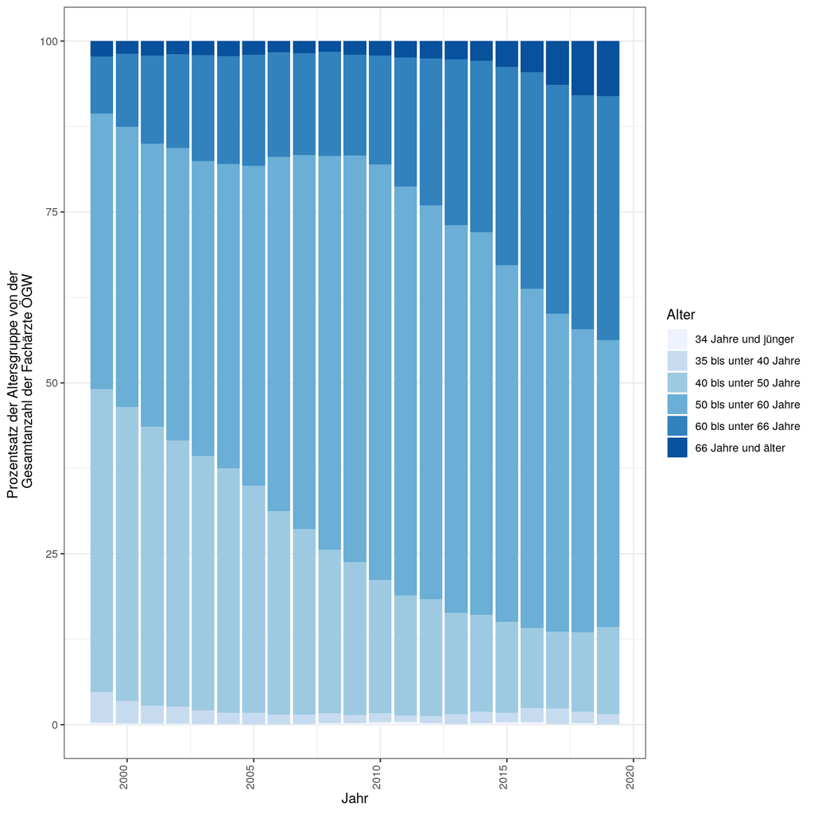

# Tabelle 4: Bei den Ärztekammern registrierte tätige Ärztinnen und Ärzte mit der Facharztbezeichnung ÖGW nach Alter in Deutschland von 1998 bis 2018 für beide Geschlechter

| Alter | Anzahl (%) in 1998 | Anzahl (%) in 2018 |
| --- | --- | --- |
| 34 Jahre und jünger | 3 (0.3%) | 0 (0%) |
| 35 bis unter 40 Jahre | 48 (4.5%) | 12 (1.5%) |
| 40 bis unter 50 Jahre | 475 (44.3%) | 100 (12.8%) |
| 50 bis unter 60 Jahre | 432 (40.3%) | 329 (42%) |
| 60 bis unter 66 Jahre | 90 (8.4%) | 280 (35.7%) |
| 66 Jahre und älter | 24 (2.2%) | 63 (8%) |

# Abbildung 5: Bei den Ärztekammern registrierte tätige Ärztinnen und Ärzte mit der Facharztbezeichnung ÖGW und alle Fachärzte nach Geschlecht und Alter (Alterspyramide) in Deutschland von 1998 bis 2018

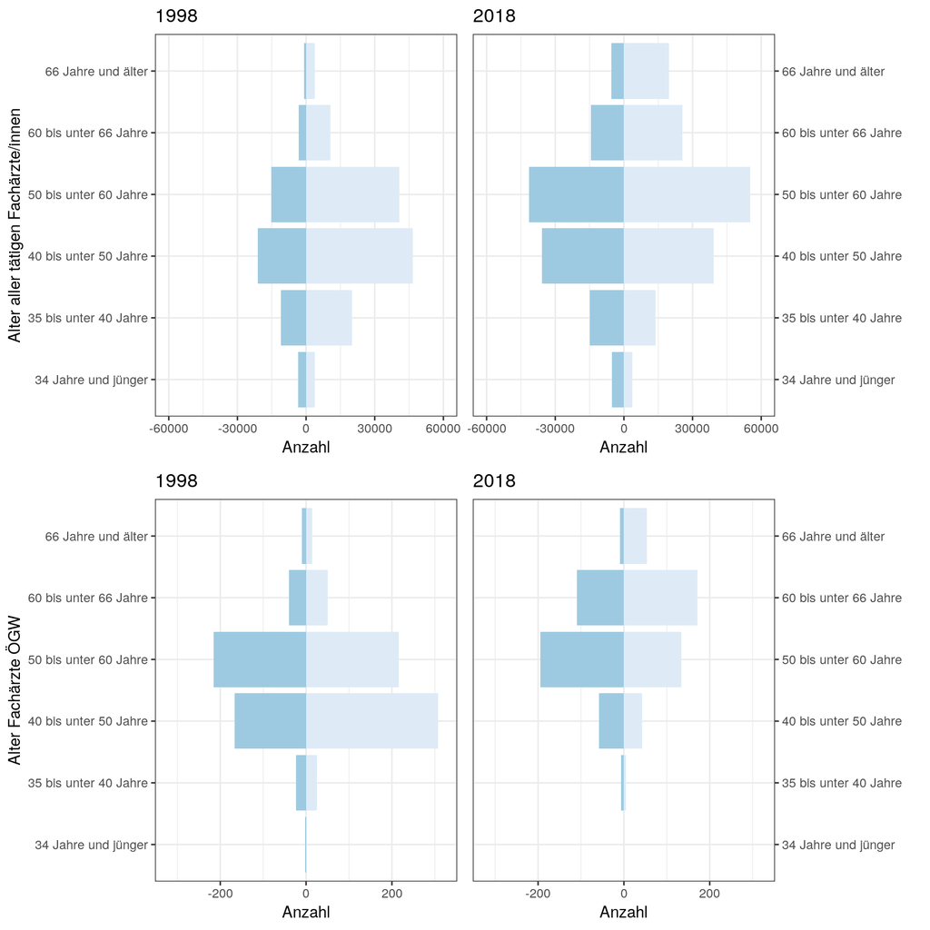

# Alter der tätigen Fachärzte nach Facharzt im Jahr 1998 und Jahr 2018

| Facharzt | Jahr1998 | Jahr2018 | Differenz |
| --- | --- | --- | --- |
| Alle Fachärzte | 47.9 | 51.6 | 3.7 |
| Allgemeinmedizin | 49.0 | 55.2 | 6.2 |
| Anästhesiologie | 45.3 | 50.0 | 4.7 |
| Anatomie | 48.6 | 53.6 | 5.0 |
| Arbeitsmedizin | 49.3 | 53.6 | 4.3 |
| Augenheilkunde | 47.6 | 51.7 | 4.1 |
| Biochemie | 49.3 | 59.5 | 10.2 |
| Chirurgie | 47.6 | 50.6 | 3.0 |
| Frauenheilkunde und Geburtshilfe | 48.3 | 51.5 | 3.2 |
| Hals-Nasen-Ohrenheilkunde | 47.4 | 51.5 | 4.1 |
| Haut- und Geschlechtskrankheiten | 47.2 | 51.3 | 4.1 |
| Humangenetik | 47.0 | 51.4 | 4.4 |
| Hygiene und Umweltmedizin | 51.3 | 54.2 | 2.9 |
| Innere Medizin | 48.5 | 50.7 | 2.2 |
| Kinder- und Jugendmedizin | 48.4 | 50.3 | 1.9 |
| Kinder- und Jugendpsychiatrie und -psychotherapie | 47.5 | 51.0 | 3.5 |
| Laboratoriumsmedizin | 49.8 | 53.7 | 3.9 |
| Mikrobiologie, Virologie, Infektionsepidemiologie | 48.1 | 52.1 | 4.0 |
| Mund-Kiefer-Gesichtschirurgie | 46.4 | 51.7 | 5.3 |
| Neurochirurgie | 45.9 | 48.7 | 2.8 |
| Neurologie | 43.0 | 47.3 | 4.3 |
| Nuklearmedizin | 47.2 | 52.0 | 4.8 |
| Öffentliches Gesundheitswesen | 50.2 | 56.9 | 6.7 |
| Pathologie | 49.3 | 51.9 | 2.6 |
| Pharmakologie | 49.9 | 54.7 | 4.8 |
| Physikalische und Rehabilitative Medizin | 47.3 | 55.6 | 8.3 |
| Physiologie | 48.9 | 55.4 | 6.5 |
| Psychiatrie und Psychotherapie | 44.1 | 52.4 | 8.3 |
| Psychosomatische Medizin und Psychotherapie | 49.4 | 59.1 | 9.7 |
| Radiologie | 47.5 | 50.1 | 2.6 |
| Rechtsmedizin | 49.6 | 51.6 | 2.0 |
| Strahlentherapie | 44.2 | 50.0 | 5.8 |
| Transfusionsmedizin | 46.9 | 53.7 | 6.8 |
| Urologie | 47.7 | 50.6 | 2.9 |